# Classification

Author

Daniel Redel

# ISLR: The Stock Market Data

## Summary Statistics

We will begin by doing some descriptive analysis of the `Smarket` data, which is part of the `ISLR2` library. This data set consists of percentage returns for the S&P 500 stock index over 1,250 days, from the beginning of 2001 until the end of 2005.

- For each date, we have recorded the percentage returns for each of the five previous trading days, `Lag1` through `Lag5`.
- It also contain a variable called `Direction` which has the two labels `"Up"` and `"Down"`.

```r
Smarket <- Smarket %>%
  rownames_to_column(var = "day") %>%
  as_tibble()
```

Table 1: Stock Market Data

| day | Year | Lag1 | Lag2 | Lag3 | Lag4 | Lag5 | Volume | Today | Direction |
| --- | --- | --- | --- | --- | --- | --- | --- | --- | --- |
| 1 | 2001 | 0.381 | -0.192 | -2.624 | -1.055 | 5.010 | 1.1913 | 0.959 | Up |
| 2 | 2001 | 0.959 | 0.381 | -0.192 | -2.624 | -1.055 | 1.2965 | 1.032 | Up |
| 3 | 2001 | 1.032 | 0.959 | 0.381 | -0.192 | -2.624 | 1.4112 | -0.623 | Down |
| 4 | 2001 | -0.623 | 1.032 | 0.959 | 0.381 | -0.192 | 1.2760 | 0.614 | Up |
| 5 | 2001 | 0.614 | -0.623 | 1.032 | 0.959 | 0.381 | 1.2057 | 0.213 | Up |
| 6 | 2001 | 0.213 | 0.614 | -0.623 | 1.032 | 0.959 | 1.3491 | 1.392 | Up |

```r
Smarket %>%
  select(-day, -Year) %>%
  tbl_summary(by = Direction, statistic = list(
    all_continuous() ~ "{mean} ({sd})"),
    digits = all_continuous() ~ 3)
```

Table 2: Summary Statistics

| **Characteristic** | **Down**, N = 602<sup>1</sup> | **Up**, N = 648<sup>1</sup> |
| --- | --- | --- |
| Lag1 | 0.051 (1.141) | -0.040 (1.131) |
| Lag2 | 0.032 (1.157) | -0.022 (1.117) |
| Lag3 | -0.006 (1.148) | 0.008 (1.130) |
| Lag4 | -0.003 (1.175) | 0.006 (1.105) |
| Lag5 | -0.001 (1.126) | 0.012 (1.168) |
| Volume | 1.470 (0.360) | 1.486 (0.361) |
| Today | -0.858 (0.754) | 0.803 (0.796) |

<sup>1</sup> Mean (SD)

Let us take a look at the correlation between the variables:

```r
correlation <- round(cor(Smarket[,2:9]),2)
```

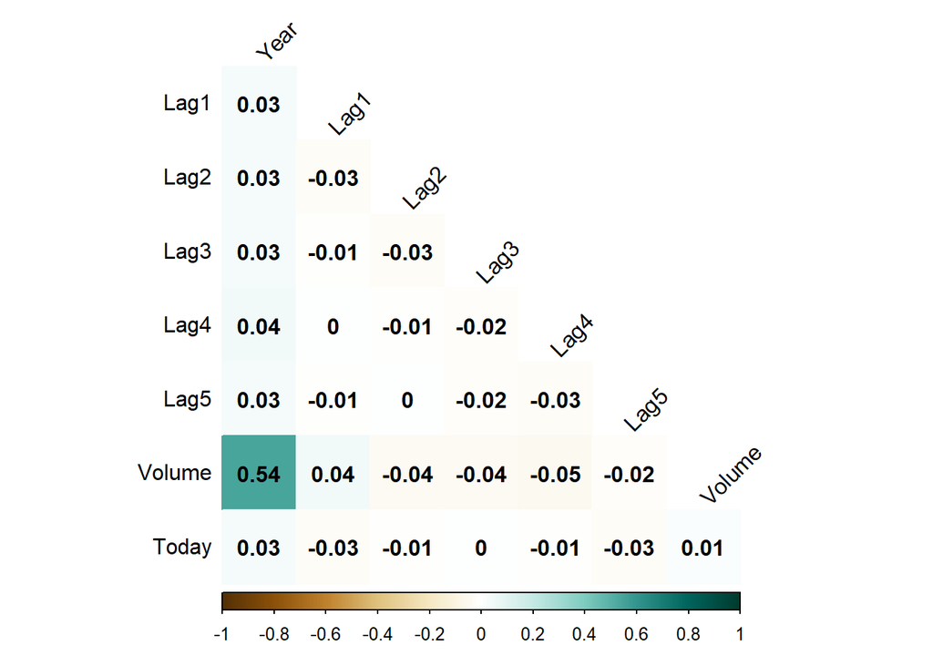

Figure 1: Correlation Matrix between Covariates

```r
corrplot(correlation, type = 'lower', method="color",
         tl.col = 'black', tl.srt = 45, # text label
         addCoef.col = "black", # coefficients
         col = COL2('BrBG'), diag=FALSE)
```

We see some positive correlation between `Year` and `Volume`. Figure 2 confirms the upward trend between these two variables:

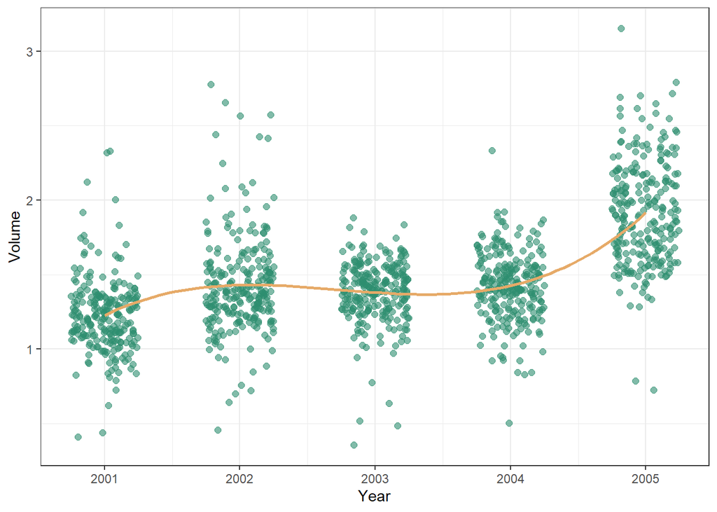

Figure 2: Time-Trend of Volume

```r
Smarket %>%
  ggplot(aes(Year, Volume)) +
  geom_jitter(width = 0.25, color = "#2D8E6F", size = 2, alpha = 0.6) +
  geom_smooth(method = lm, formula = y ~ splines::bs(x, 3), se = FALSE, color = "#E6AA68", alpha = 0.7) +
  theme_bw()
```

## Logistic Regression

Next, we will fit a logistic regression model in order to predict `Direction` using `Lag1` through `Lag5` and `Volume`:

```r
Smarket <- Smarket %>%
mutate(Direction1 = ifelse(Direction == "Down",0,1))
```

```r
glm.fit <- glm(Direction ~ Lag1 + Lag2 + Lag3 + Lag4 + Lag5 + Volume, data = Smarket, family = binomial(link="logit"))
```

```r
summary(glm.fit)$coef %>%
  round(3) %>%
  kbl() %>%
  kable_styling(bootstrap_options = c("striped", "hover", "condensed"))
```

Table 3: Logistic Regression Results

|  | Estimate | Std. Error | z value | Pr(>\|z\|) |
| --- | --- | --- | --- | --- |
| (Intercept) | -0.126 | 0.241 | -0.523 | 0.601 |
| Lag1 | -0.073 | 0.050 | -1.457 | 0.145 |
| Lag2 | -0.042 | 0.050 | -0.845 | 0.398 |
| Lag3 | 0.011 | 0.050 | 0.222 | 0.824 |
| Lag4 | 0.009 | 0.050 | 0.187 | 0.851 |
| Lag5 | 0.010 | 0.050 | 0.208 | 0.835 |
| Volume | 0.135 | 0.158 | 0.855 | 0.392 |

### Prediction

Predictions are done much the same way. Here we use the model to predict on the data it was trained on.

```r
# Predicted x'beta
xb <- predict(glm.fit, type = "link", newdata = Smarket)
# Predicted probability
prob <- predict(glm.fit, type = "response", newdata = Smarket)
```

```r
head(cbind(xb,prob)) %>%
  round(3) %>%
  kbl() %>%
  kable_styling(bootstrap_options = c("striped", "hover", "condensed"))
```

| xb | prob |
| --- | --- |
| 0.028 | 0.507 |
| -0.074 | 0.481 |
| -0.075 | 0.481 |
| 0.061 | 0.515 |
| 0.043 | 0.511 |
| 0.028 | 0.507 |

We can build a **confusion matrix** to assess prediction accuracy:

```r
pred_Smarket <- cbind(Smarket, xb, prob)
pred_Smarket$Prediction <- rep("Down", 1250)
pred_Smarket$Prediction[prob > 0.5] <- "Up"
```

```r
pred_Smarket %>%
  mutate(Prediction = as.factor(Prediction)) %>%
  conf_mat(truth = Direction, estimate = Prediction)
```

```
          Truth
Prediction Down  Up
      Down  145 141
      Up    457 507
```

Alternatively, the package `yardstick` provides some useful functions to evaluate model performance. For example, we can get the `acuracy()`:

```r
pred_Smarket %>%
  mutate(Prediction = as.factor(Prediction)) %>%
  accuracy(truth = Direction, estimate = Prediction) %>%
  kbl() %>%
  kable_styling(bootstrap_options = c("striped", "hover", "condensed"))
```

| .metric | .estimator | .estimate |
| --- | --- | --- |
| accuracy | binary | 0.5216 |

**What is the percentage of negatives (in this case, `Direction=Up`) correctly identified?** That is defined by the *Specificity* metric:

```r
pred_Smarket %>%
  mutate(Prediction = as.factor(Prediction)) %>%
  spec(truth = Direction, estimate = Prediction) %>%
  kbl() %>%
  kable_styling(bootstrap_options = c("striped", "hover", "condensed"))
```

| .metric | .estimator | .estimate |
| --- | --- | --- |
| spec | binary | 0.7824074 |

We can use the `confusionMatrix()` function from the `caret` package to have a more detailed assessment:

```r
cm <- confusionMatrix(factor(pred_Smarket$Prediction),
                      factor(pred_Smarket$Direction),
                      dnn = c("Prediction", "Direction"))
cm
```

```
Confusion Matrix and Statistics

          Direction
Prediction Down  Up
      Down  145 141
      Up    457 507

               Accuracy : 0.5216
                 95% CI : (0.4935, 0.5496)
    No Information Rate : 0.5184
    P-Value [Acc > NIR] : 0.4216

                  Kappa : 0.0237

 Mcnemar's Test P-Value : <2e-16

            Sensitivity : 0.2409
            Specificity : 0.7824
         Pos Pred Value : 0.5070
         Neg Pred Value : 0.5259
             Prevalence : 0.4816
         Detection Rate : 0.1160
   Detection Prevalence : 0.2288
      Balanced Accuracy : 0.5116

       'Positive' Class : Down
```

A more visual representation of the confusion matrix can be done by generating a `ggplot2` chart:

```r
plt <- as.data.frame(cm$table)

plotTable <- plt %>%
  mutate(Correct = ifelse(plt$Prediction == plt$Direction, "TRUE", "FALSE")) %>%
  group_by(Direction) %>%
  mutate(prop = Freq/sum(Freq))
```

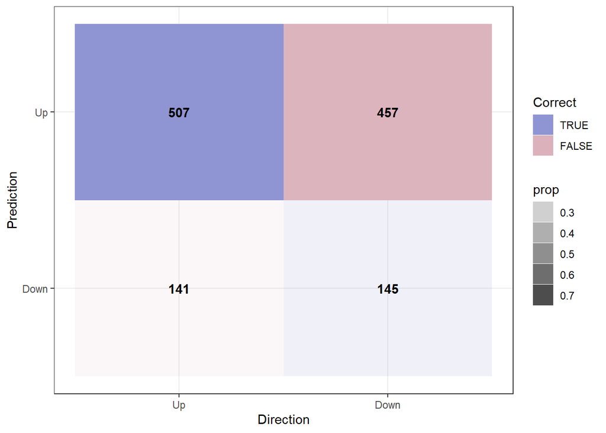

Figure 3: Confusion Matrix: Logistic Regression

```r
ggplot(plotTable, aes(x = Direction, y = Prediction, fill = Correct, alpha = prop)) +
  geom_tile() +
  geom_text(aes(label = Freq), vjust = .5, fontface  = "bold", alpha = 1) +
  scale_fill_manual(values = c("TRUE" = "#8F95D3", "FALSE" = "#DBB1BC")) +
  theme_bw() +
  xlim(rev(levels(plt$Direction)))
```

### Out-Of-Sample Performance

We have just said something about the *training error rate*. As we have seen previously, the training error rate is often overly optimistic—it tends to underestimate the **test error rate**.

In order to better assess the accuracy of the logistic regression model in this setting, we can fit the model using part of the data, and then examine how well it predicts the *held out data*.

Since we are working with some data that has a time component, it is natural to fit the model using the observations form `2001` to `2004` and evaluate it on the last year of `2005`. This would more closely match how such a model would be used in real life:

```r
Smarket_train <- Smarket %>%
  filter(Year <= 2004)
Smarket_test <- Smarket %>%
  filter(Year == 2005)
```

```r
glm_fit <- glm(Direction ~ Lag1 + Lag2 + Lag3 + Lag4 + Lag5 + Volume,
               data = Smarket_train,
               family = binomial)
```

Predicting using the test data:

```r
prob <- predict(glm_fit, type = "response", newdata = Smarket_test)
pred_Smarket_test <- cbind(Smarket_test, prob)
pred_Smarket_test$Prediction <- rep("Down", nrow(Smarket_test))
pred_Smarket_test$Prediction[prob > 0.5] <- "Up"
```

```r
confusion_test1 <- table(Prediction = factor(pred_Smarket_test$Prediction),
      Direction = factor(pred_Smarket_test$Direction))
```

```
Accuracy: 0.48
```

The results are rather disappointing: the accuracy is 48%, which is worse than random guessing!

Perhaps by removing the variables that appear not to be helpful in predicting Direction, we can obtain a more effective model.

```r
glm_fit_minimal <- glm(Direction ~ Lag1 + Lag2, data = Smarket_train,
                       family = binomial)
```

```r
prob <- predict(glm_fit_minimal, type = "response", newdata = Smarket_test)
pred_Smarket_test <- cbind(Smarket_test, prob)
pred_Smarket_test$Prediction <- rep("Down", nrow(Smarket_test))
pred_Smarket_test$Prediction[prob > 0.5] <- "Up"
```

```r
confusion_test2 <- table(Prediction = factor(pred_Smarket_test$Prediction),
      Direction = factor(pred_Smarket_test$Direction))
```

```
Accuracy: 0.56
```

## Linear Discriminant Analysis

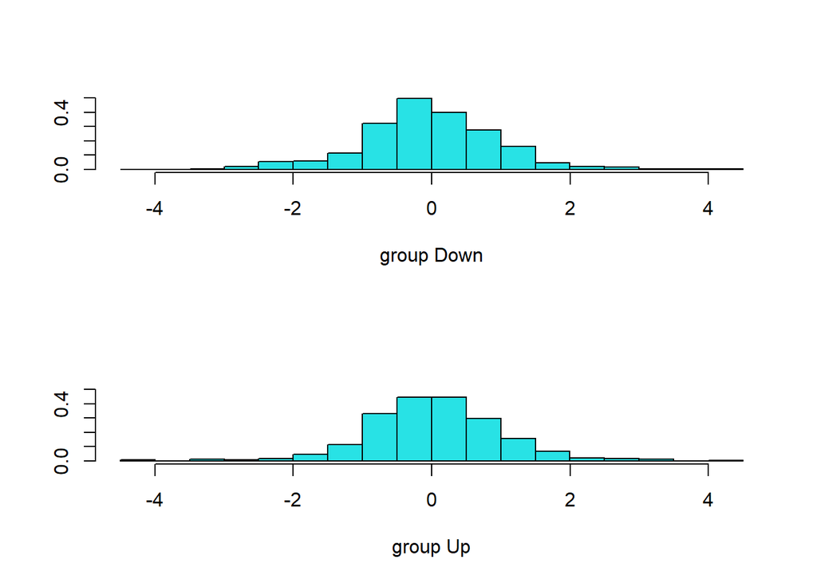

```r
lda.fit <- MASS::lda(Direction ~ Lag1 + Lag2, data = Smarket_train)
plot(lda.fit)
```

Predictions are done using the test data:

```r
prediction_lda <- predict(lda.fit, newdata = Smarket_test)
lda_Smarket <- cbind(Smarket_test, Prediction = prediction_lda$class)
```

```r
lda_Smarket  %>%
  mutate(Prediction = as.factor(Prediction)) %>%
  conf_mat(truth = Direction, estimate = Prediction)
```

```
          Truth
Prediction Down  Up
      Down   35  35
      Up     76 106
```

```r
cm <- confusionMatrix(factor(lda_Smarket$Prediction),
                      factor(lda_Smarket$Direction),
                      dnn = c("Prediction", "Direction"))
plt <- as.data.frame(cm$table)
plotTable <- plt %>%
  mutate(Correct = ifelse(plt$Prediction == plt$Direction, "TRUE", "FALSE")) %>%
  group_by(Direction) %>%
  mutate(prop = Freq/sum(Freq))
```

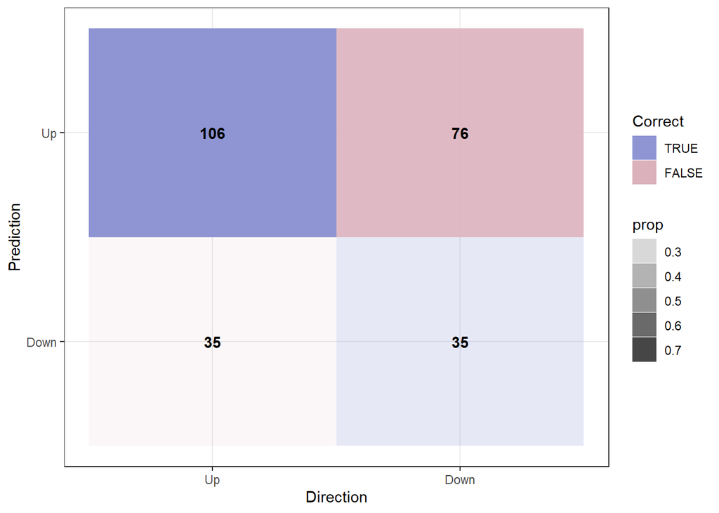

Figure 4: Confusion Matrix: Linear Discriminant Analysis

```r
ggplot(plotTable, aes(x = Direction, y = Prediction, fill = Correct, alpha = prop)) +
  geom_tile() +
  geom_text(aes(label = Freq), vjust = .5, fontface  = "bold", alpha = 1) +
  scale_fill_manual(values = c("TRUE" = "#8F95D3", "FALSE" = "#DBB1BC")) +
  theme_bw() +
  xlim(rev(levels(plt$Direction)))
```

```
Accuracy: 0.56
```

Applying a 50% threshold to the posterior probabilities allows us to recreate the predictions contained in `lda.pred$class`.

```r
sum(prediction_lda$posterior[, 1] >= 0.5)
```

```
[1] 70
```

```r
sum(prediction_lda$posterior[, 1] < 0.5)
```

```
[1] 182
```

## Quadratic Discriminant Analysis

We will now fit a QDA model:

```r
qda.fit <- MASS::qda(Direction ~ Lag1 + Lag2, data = Smarket_train)
```

```r
prediction_qda <- predict(qda.fit, newdata = Smarket_test)
qda_Smarket <- cbind(Smarket_test, Prediction = prediction_qda$class)
```

```r
cm <- confusionMatrix(factor(qda_Smarket$Prediction),
                      factor(qda_Smarket$Direction),
                      dnn = c("Prediction", "Direction"))
plt <- as.data.frame(cm$table)
plotTable <- plt %>%
  mutate(Correct = ifelse(plt$Prediction == plt$Direction, "TRUE", "FALSE")) %>%
  group_by(Direction) %>%
  mutate(prop = Freq/sum(Freq))
```

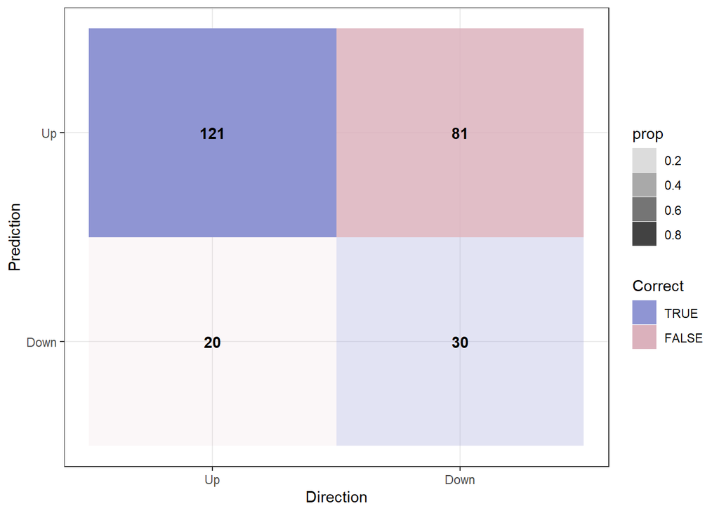

Figure 5: Confusion Matrix: Quadratic Discriminant Analysis

```r
ggplot(plotTable, aes(x = Direction, y = Prediction, fill = Correct, alpha = prop)) +
  geom_tile() +
  geom_text(aes(label = Freq), vjust = .5, fontface  = "bold", alpha = 1) +
  scale_fill_manual(values = c("TRUE" = "#8F95D3", "FALSE" = "#DBB1BC")) +
  theme_bw() +
  xlim(rev(levels(plt$Direction)))
```

```
Accuracy: 0.599
```

## Naive Bayes

Next, we fit a naive Bayes model to the `Smarket` data. Naive Bayes is implemented in `R` using the `naiveBayes()` function, which is part of the `e1071` library.

```r
nbayes.fit <- naiveBayes(Direction ~ Lag1 + Lag2, data = Smarket_train)
```

```r
prediction_nbayes <- predict(nbayes.fit , newdata = Smarket_test)
nbayes_Smarket <- cbind(Smarket_test, Prediction = prediction_nbayes)
```

```r
cm <- confusionMatrix(factor(nbayes_Smarket$Prediction),
                      factor(nbayes_Smarket$Direction),
                      dnn = c("Prediction", "Direction"))
plt <- as.data.frame(cm$table)
plotTable <- plt %>%
  mutate(Correct = ifelse(plt$Prediction == plt$Direction, "TRUE", "FALSE")) %>%
  group_by(Direction) %>%
  mutate(prop = Freq/sum(Freq))
```

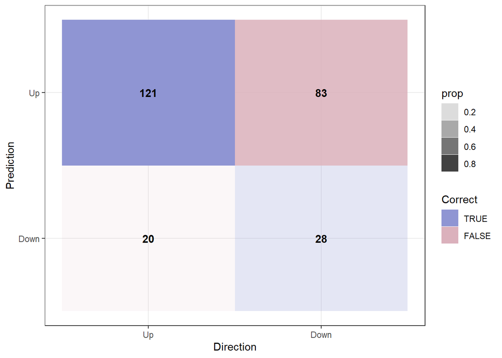

```r
ggplot(plotTable, aes(x = Direction, y = Prediction, fill = Correct, alpha = prop)) +
  geom_tile() +
  geom_text(aes(label = Freq), vjust = .5, fontface  = "bold", alpha = 1) +
  scale_fill_manual(values = c("TRUE" = "#8F95D3", "FALSE" = "#DBB1BC")) +
  theme_bw() +
  xlim(rev(levels(plt$Direction)))
```

```
Accuracy: 0.591
```

## K-Nearest Neighbors

We will now perform KNN using the `knn()` function, which is part of the `class` library. First we need to re-arrange our train and test data:

```r
train_x <-  Smarket_train %>%
  dplyr::select(Lag1, Lag2)

test_x <- Smarket_test %>%
  dplyr::select(Lag1, Lag2)

train_y <- Smarket_train %>%
  dplyr::select(Direction)
```

```r
set.seed(1)
knn_pred <- knn(as.matrix(train_x),
                as.matrix(test_x),
                as.matrix(train_y),
                k = 3)
```

```r
table(knn_pred, Smarket_test[["Direction"]])
```

```
knn_pred Down Up
    Down   48 55
    Up     63 86
```

```
Accuracy: 0.532
```

It appears that this model is not performing that well.